# Quiz 1

Simon Halliday

2015-September -24

Load the packages you require: `mosaicData` and `DataComputing`:

```r
library(mosaicData)
library(DataComputing)
```

I picked a name randomly from the class and got “Riley”. We shall investigate a little bit about that name using the `BabyNames` datatable provided in `mosaicData`.

I ran the following command to create a data table called `Riley` to provide a table with the total of all people called Riley in the `BabyNames` data table.

Copy and paste this command into your console or R markdown in a data chunk and run it.

```r
Riley <-
  BabyNames %>%
  filter(name == "Riley") %>%
  group_by(year, sex) %>%
  summarise(yearlytotal = sum(count))
```

You should now have an object in your “Environment” tab called “Riley”.

### head()

For the question in the quiz, you need to use the function `head()` to find out how many people are called Riley at the top of the data table Riley.

```r
head(Riley)
```

### favstats()

Run the `favstats()` function to find the summary statistics of the variable `yearlytotal` with the data table `Riley`.

What is the mean value of `yearlytotal` rounded to the closest unit?

### filter() and FemRiley

Now, we need to `filter()` this table to create a new data table (I called mine `FemRiley`) to get a data table that includes only the female cases called Riley. (Don’t forget to use two `=` signs for your condition, e.g. `==`):

Now, for the quiz, we need to find out what the first year was in which a female was called Riley in the data. We can do this by using the `head()` function on our `FemRiley` data table.

### dim() of FemRiley

For the next question in the quiz you need to find out the dimensions of your DataTable. To find out the dimensions of a data table we use the function `dim()`:

```r
dim(FemRiley)
```

### FemRiley1995

For the next question in the quiz, you need to calculate the number of females called Riley in the 1995 (I don’t know what year Riley in ECO254 at Smith was born, but I took an educated guess; Riley, apologies if I got it incorrect.) Once more, use filter to create an object called FemRiley1995 with only those people called Riley and born in 1995 in the object FemRiley1995. You will need to use your insight from the class to do this.

Display your total in the console (or in your knitted R markdown) calling on the data table’s name:

```r
FemRiley1995
```

### Final Aside

Note, you could also have just typed `View(FemRiley)` in the console and scrolled until you got to 1995 to check how many women named Riley were born in that year, rather than creating a new object. But creating a new object is good practise for things yet to come.

### Bonus Graphic: Kerry over time

Let’s move away from Riley and pick another person’s name from class, “Kerry”. We can see how the totals of males and females named Kerry has changed over time.

The code below shows what we’d need to do to get the data for the name Kerry and then put it into a ggplot (we start to use `ggplot` next week for visualization; this graphic is here purely for you to look at what you think might be going on). Also, if you want to, you can substitute each instance of the name “Kerry” in the codebloc for a name that you want to investigate to see what has happened to that name over time. You’ll notice that some names are *never* used for males and some names are *never* used for females (unlike Riley, Kerry or Darcy), try Kitty, Paula, Hera or Mariko to see what I mean.

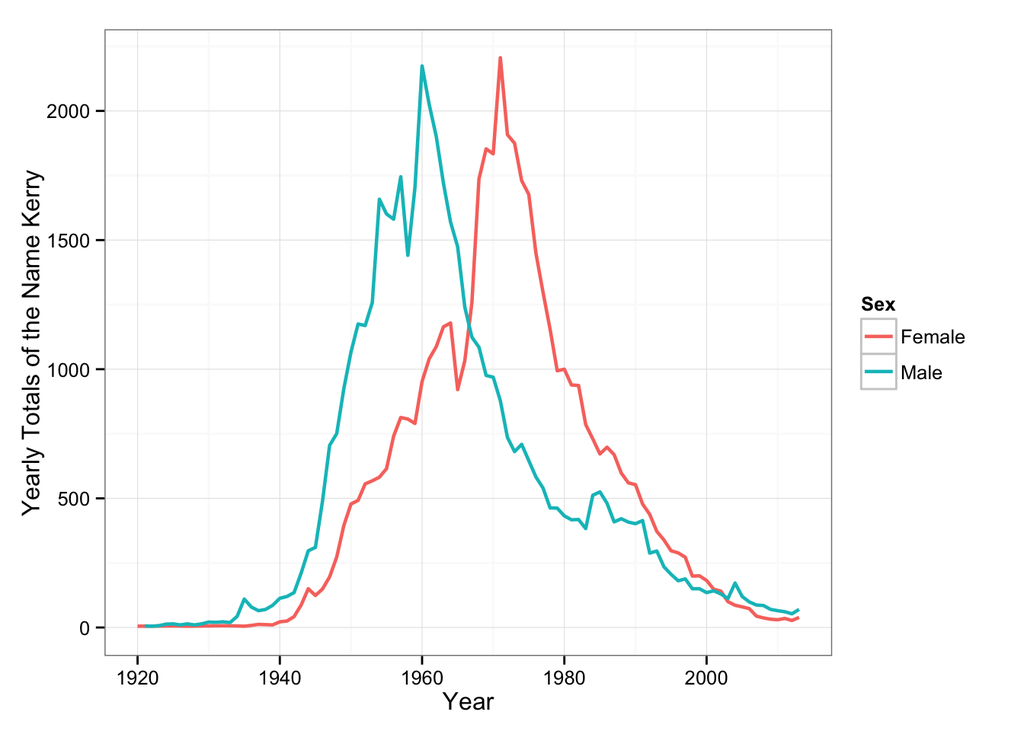

```r
Kerry <-
  BabyNames %>%
  filter(name == "Kerry") %>%
  group_by(year, sex) %>%
  summarise(yearlytotal = sum(count))
Kerry %>%
  ggplot(aes(x = year, y = yearlytotal, color = sex)) +
  geom_line(size = 0.8) +
  ylim(0, NA) +
  ylab("Yearly Totals of the Name Kerry") +
  xlab("Year") +
  scale_color_discrete(name="Sex",
                         breaks=c("F", "M"),
                         labels=c("Female", "Male")) +
  theme_bw()
```